# Motivation for isotwas

`isotwas` provides functions to run transcriptome-wide association studies on the isoform-level.

Isoform-level analyses can provide further granularity to a gene-trait association by pinpointing the isoform of a given gene that drives the association. Furthermore, if two isoforms of the same genes have associations with divergent effect sizes, then gene-level trait mapping will likely miss this association but isoform-level trait mapping will not.

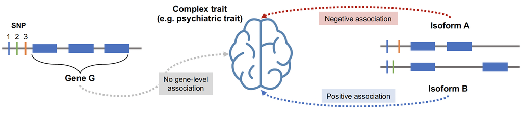

`isotwas` contains functions for:

1. **Training multivariate predictive models** for isoform-level expression from genetic variants, with 9 different methods including:
   - MRCE (Multivariate Regression with Covariance Estimation)
   - Multivariate elastic net
   - Joinet stacked elastic net
   - Sparse PLS
   - Sparse group lasso
   - Multi-task lasso (L21 regularization)
   - Super learner stacking
   - Graph-regularized regression (using isoform similarity)
   - Univariate methods (elastic net, BLUP, SuSiE)
2. **Conducting trait mapping** on the isoform-level using stage-wise hypothesis testing
3. **Probabilistic fine-mapping** to identify causal isoforms

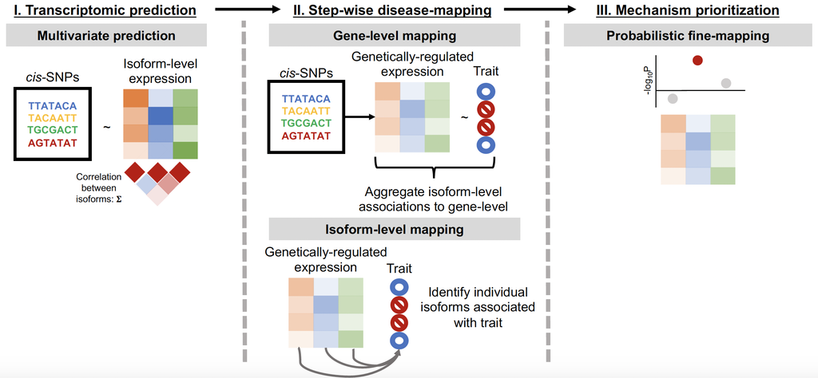

## Key Features

- **Multiple prediction methods**: The package automatically evaluates multiple multivariate regression methods and selects the best model based on cross-validated R-squared.
- **Graph-regularized learning**: Incorporate prior knowledge about isoform similarity (e.g., shared exon structure) to improve predictions.
- **User-friendly interface**: The main `compute_isotwas()` function provides detailed progress output, data summaries, and results comparison tables.
- **Robust model selection**: Uses cross-validation within each method and compares across methods to find the optimal model for each gene.

See the Train an isoTWAS model vignette for detailed usage instructions.